# Wearable data classificator

Rafael Gurgel

03/02/2018

## Overview

This report explores a large amouth of data from weareable devices, using them to predict the quality of the exercice’s movement as a requirement to complete the Practical Machine Learning course on Coursera. The data is provided by PUC-RIO and divided in 2 groups, 19622 observations of 160 variables for training and other 20 observations as a test. All the code is available on [Github](https://github.com/rafagurgel/PML_CourseProject).

## Data Analysis

### Pre-process

```r
training <- fread("https://d396qusza40orc.cloudfront.net/predmachlearn/pml-training.csv",
                  na.strings=c("NA"," ","#DIV/0!"))
testing <- fread("https://d396qusza40orc.cloudfront.net/predmachlearn/pml-testing.csv",
                 na.strings=c("NA"," ","#DIV/0!"))

training <- training%>%
    mutate_at(vars(roll_belt:magnet_forearm_z),funs(suppressWarnings(as.double(.))))%>%
    mutate(user_name = factor(user_name),
           raw_timestamp_part_1 = factor(raw_timestamp_part_1),
           raw_timestamp_part_2 = factor(raw_timestamp_part_2),
           cvtd_timestamp = dmy_hm(cvtd_timestamp),
           num_window = factor(num_window),
           classe = factor(classe))%>%
    as_tibble

testing <- testing%>%
    select(-problem_id)%>%
    mutate_at(vars(roll_belt:magnet_forearm_z),funs(suppressWarnings(as.double(.))))%>%
    mutate(user_name = factor(user_name),
           raw_timestamp_part_1 = factor(raw_timestamp_part_1),
           raw_timestamp_part_2 = factor(raw_timestamp_part_2),
           cvtd_timestamp = dmy_hm(cvtd_timestamp),
           num_window = factor(num_window))%>%
    as_tibble
```

The first 7 variables isn’t relevant for the prediction, so it’ll be removed from datasets

```r
names(training)[1:7]
```

```
## [1] "V1"                   "user_name"            "raw_timestamp_part_1"
## [4] "raw_timestamp_part_2" "cvtd_timestamp"       "new_window"
## [7] "num_window"
```

```r
training <- training%>%
    select(-c(V1:num_window))
testing <- testing%>%
    select(-c(V1:num_window))
```

Leaving us with 153 variables (including the variable to be predicted). Many of this variables have NA values, let’s check the NA proportion by some thresholds. There are 53 variables with some value in every row, so 100 variables have at least one missing value (indeed those variables has over than 97% of their data missing and 6 variables misses all their values as we can see in the figure below).

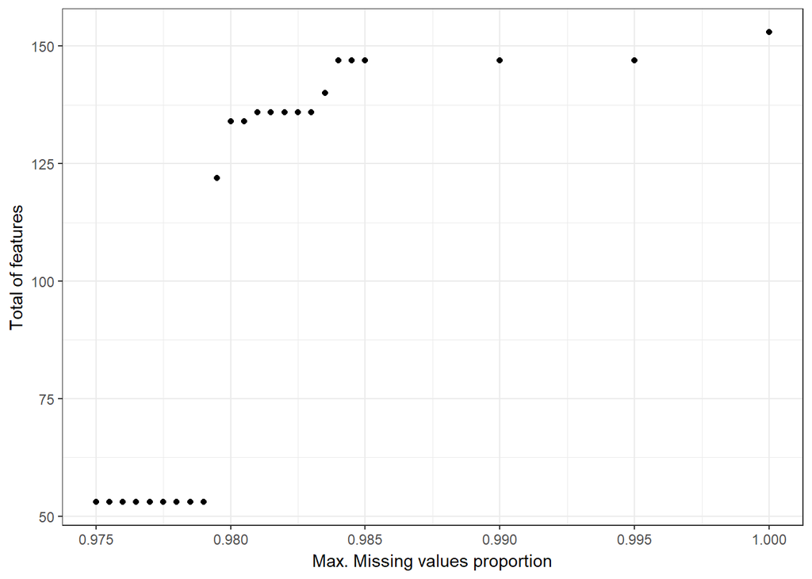

```r
# Removing NA
cols<-training%>%
    summarize_all(funs(sum(is.na(.))/n()))%>%
    select(which(. <0.975))%>%
    colnames%>%
    as.vector
training <- training%>%
    select(cols)
# Dividing the data
set.seed(20180205)
inTrain <- createDataPartition(y=training$classe,p=0.8, list=FALSE)
```

## Results

We fitted a Random Forest model and to reduce the probability of the overfitting, a 5-fold cross validation was performed. Usually Random Forests tend to overfit the data.

```r
fit<-train(classe~.,
              method="rf",
              data=training[inTrain,],
              preProcess = c("center","scale"),
              trControl = trainControl(method = "cv",number = 5))
fit
```

```
## Random Forest
##
## 15699 samples
##    52 predictor
##     5 classes: 'A', 'B', 'C', 'D', 'E'
##
## Pre-processing: centered (52), scaled (52)
## Resampling: Cross-Validated (5 fold)
## Summary of sample sizes: 12559, 12559, 12559, 12558, 12561
## Resampling results across tuning parameters:
##
##   mtry  Accuracy   Kappa
##    2    0.9932481  0.9914584
##   27    0.9928661  0.9909756
##   52    0.9840757  0.9798558
##
## Accuracy was used to select the optimal model using the largest value.
## The final value used for the model was mtry = 2.
```

The model looks highly accurate (99%), but as previously discussed about Random Forest overfitting’s tendency, it’s important validate it.

```r
pred<-predict(fit,training[-inTrain,])
class<- training[-inTrain,]$classe
confusionMatrix(pred,class)
```

```
## Confusion Matrix and Statistics
##
##           Reference
## Prediction    A    B    C    D    E
##          A 1115    5    0    0    0
##          B    1  753    5    0    0
##          C    0    1  679   14    0
##          D    0    0    0  628    0
##          E    0    0    0    1  721
##
## Overall Statistics
##
##                Accuracy : 0.9931
##                  95% CI : (0.99, 0.9955)
##     No Information Rate : 0.2845
##     P-Value [Acc > NIR] : < 2.2e-16
##
##                   Kappa : 0.9913
##  Mcnemar's Test P-Value : NA
##
## Statistics by Class:
##
##                      Class: A Class: B Class: C Class: D Class: E
## Sensitivity            0.9991   0.9921   0.9927   0.9767   1.0000
## Specificity            0.9982   0.9981   0.9954   1.0000   0.9997
## Pos Pred Value         0.9955   0.9921   0.9784   1.0000   0.9986
## Neg Pred Value         0.9996   0.9981   0.9985   0.9954   1.0000
## Prevalence             0.2845   0.1935   0.1744   0.1639   0.1838
## Detection Rate         0.2842   0.1919   0.1731   0.1601   0.1838
## Detection Prevalence   0.2855   0.1935   0.1769   0.1601   0.1840
## Balanced Accuracy      0.9987   0.9951   0.9940   0.9883   0.9998
```

Great! A 99% accuracy, then it looks that there’s no overfit in our data. So let’s finally predict the testing data leading to the following results.

```r
predict(fit,testing)
```

```
##  [1] B A B A A E D B A A B C B A E E A B B B
## Levels: A B C D E
```

Checking the results in the quiz and we’ve got 100%!

## References

Ugulino, W.; Cardador, D.; Vega, K.; Velloso, E.; Milidiu, R.; Fuks, H. Wearable Computing: Accelerometers’ Data Classification of Body Postures and Movements. Proceedings of 21st Brazilian Symposium on Artificial Intelligence. Advances in Artificial Intelligence - SBIA 2012. In: Lecture Notes in Computer Science. , pp. 52-61. Curitiba, PR: Springer Berlin / Heidelberg, 2012. ISBN 978-3-642-34458-9. DOI: 10.1007/978-3-642-34459-6_6.